# Tail slope estimation

Use `sample_growth_tb` and `sample_size_tb` to calculate the tail index $\alpha$, the reciprocal of the Hill estimator. The analyses cover income ratios over 2014–2020, income at age 25 in 2020, and age-specific income for ages 25–60 in 2020. When the upper tail has the following form, define $\alpha$ as the reciprocal of the Hill estimator $\gamma$.

$$\overline F(x)=Cx^{-\alpha}, \qquad x\geq u>0.$$

## 0 Data preparation

```r
library(tidyverse)
library(pins)
# Specify relative paths for the board, figure output directory, and plotting theme.
board <- board_folder("../income_board_replicate")
graph_dir <- "graph"
dir.create(graph_dir, recursive = TRUE, showWarnings = FALSE)
source("theme_ipsum_like.R")
theme_set(theme_ipsum())
```

Load growth and income data and add age as the calendar year minus the birth year in the first four characters of `birth_date`. For growth data, age is measured at the beginning of each period; for income data, it is measured in the observation year. Restrict growth data to beginning-of-period income of at least 4 million yen and beginning-of-period ages 25–60. Store positive-income observations for 2020 in `income_2020_tb`, applying age conditions separately in each analysis.

```r
sample_growth_tb <- board |> pin_read("sample_growth_tb") |>
  mutate(age = as.numeric(str_c(20, str_sub(year,6,7))) - as.numeric(str_sub(birth_date, 1, 4))) |>
  filter(pre_income >= 4*10^6,
         age >= 25, age <= 60)

sample_size_tb <- board |> pin_read("sample_size_tb") |>
  mutate(age = as.numeric(year) - as.numeric(str_sub(birth_date, 1, 4)))

income_2020_tb <- sample_size_tb |>
  filter(year == "2020", main_var > 0)
```

The shared function `hill_alpha()` extracts the Hill estimator $\gamma$ from `ReIns::Hill()` and returns its reciprocal $\alpha=1/\gamma$. Use `print_hill_estimates()` to display the baseline rank `k_n`, five times and ten times that rank, and the tail index estimates.

```r
hill_alpha <- function(x) {
  c(ReIns::Hill(x)$gamma, NA)^(-1)
}

print_hill_estimates <- function(alpha, k_n) {
  k_values <- floor(c(1, 5, 10) * k_n)

  cat(
    str_c(
      c("k_n", "5*k_n", "10*k_n"),
      " is ", k_values,
      "; alpha is ", round(alpha[k_values], digits = 3),
      collapse = "\n"
    ),
    "\n"
  )
}
```

## 1 Long-term growth over 2014–2020

Extract log growth over 2014–2020 (`g_20_14`) for observations with income of at least 4 million yen and age 25–60 in 2014. Apply Hill estimation to the income ratio obtained by exponentiating log growth, $\exp(g_{20,14})=Y_{2020}/Y_{2014}$. Set the baseline threshold to $k_n=0.001n$. Here, $n$ is the number of observations satisfying the 2014 income and age conditions.

```r
sample_tb <- sample_growth_tb |>
  filter(year == "g_20_14", is.finite(growth)) |>
  arrange(desc(growth)) |>
  mutate(i_var = 1:n(), n_i_var = n()/i_var)

res_hill_tb <- sample_tb |> mutate(alpha = hill_alpha(exp(growth)))
k_n <- nrow(sample_tb) * 0.001

print_hill_estimates(res_hill_tb$alpha, k_n)
```

```
k_n is 892; alpha is 1.503
5*k_n is 4460; alpha is 1.688
10*k_n is 8920; alpha is 1.837
```

## 2 Income distribution at age 25 in 2020

Select observations at age 25 from `income_2020_tb`, sort income `main_var` in descending order, and apply Hill estimation. Initial income refers to income at age 25. Set the baseline threshold to $k_n=0.01n$, or 1% of this sample’s size $n$.

```r
sample_tb <- income_2020_tb |>
  filter(age == 25) |>
  arrange(desc(main_var)) |>
  mutate(i_var = 1:n(), n_i_var = n()/i_var)

res_hill_tb <- sample_tb |> mutate(alpha = hill_alpha(main_var))
k_n <- nrow(sample_tb) * 0.01

print_hill_estimates(res_hill_tb$alpha, k_n)
```

```
k_n is 294; alpha is 1.776
5*k_n is 1470; alpha is 2.197
10*k_n is 2941; alpha is 2.369
```

## 3 Income distributions by age in 2020

Use positive-income observations aged 25–60 in 2020. For each age, sort income in descending order and calculate the tail index $\alpha(i)$ as the number of upper-order observations varies.

```r
sample_tb <- income_2020_tb |>
  filter(!is.na(age), age >= 25, age <= 60) |>
  arrange(desc(main_var)) |>
  group_by(age) |>
  mutate(i_var = 1:n(), n_i_var = n()/i_var)

res_hill_tb <- sample_tb |> mutate(alpha = hill_alpha(main_var))
```

With the number of upper-order observations $i$ on the horizontal axis, compare the estimated series for $i<4000$, colored by age.

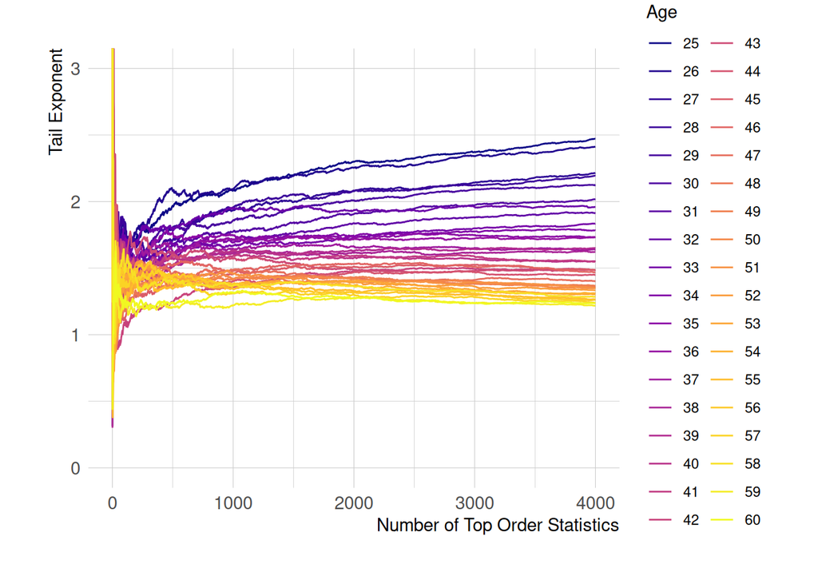

```r
res_hill_tb |>
  mutate(age = str_pad(age, 2, pad = "0") |> as.character()) |>
  filter(i_var < 4000) |>
ggplot() +
  geom_line(aes(i_var, alpha, color = age)) +
  scale_color_viridis_d(option = "C") +
  coord_cartesian(ylim = c(0, 3)) +
  labs(
      x = "Number of Top Order Statistics",
      y = "Tail Exponent",
      color = "Age",
  )
ggsave(filename = "Hill_est_firm_size_diff_age_income.png", path = graph_dir)
```